# Common Errors

D. Howell

9/11/2020

> At the source of every error which is blamed on the computer you will find at least two human errors, including the error of blaming it on the computer. - Tom Gilb

> There are two ways to write error-free programs; only the third works. - Alan Perlis

### Common "pre-error" mistakes

- mismatching parentheses

```r
try(
  print(rep('nice', 25))
)
```

```
##  [1] "nice" "nice" "nice" "nice" "nice" "nice" "nice" "nice" "nice" "nice"
## [11] "nice" "nice" "nice" "nice" "nice" "nice" "nice" "nice" "nice" "nice"
## [21] "nice" "nice" "nice" "nice" "nice"
```

```r
try(
  print(rep('nice'), 25)
)
```

```
## Error in print.default(rep("nice"), 25) : invalid printing digits 25
```

```r
# try(
#   print(rep('nice'), 25))
# )
# try(
#   print(rep('nice', 25)
# )
```

- executing code from a script out of order

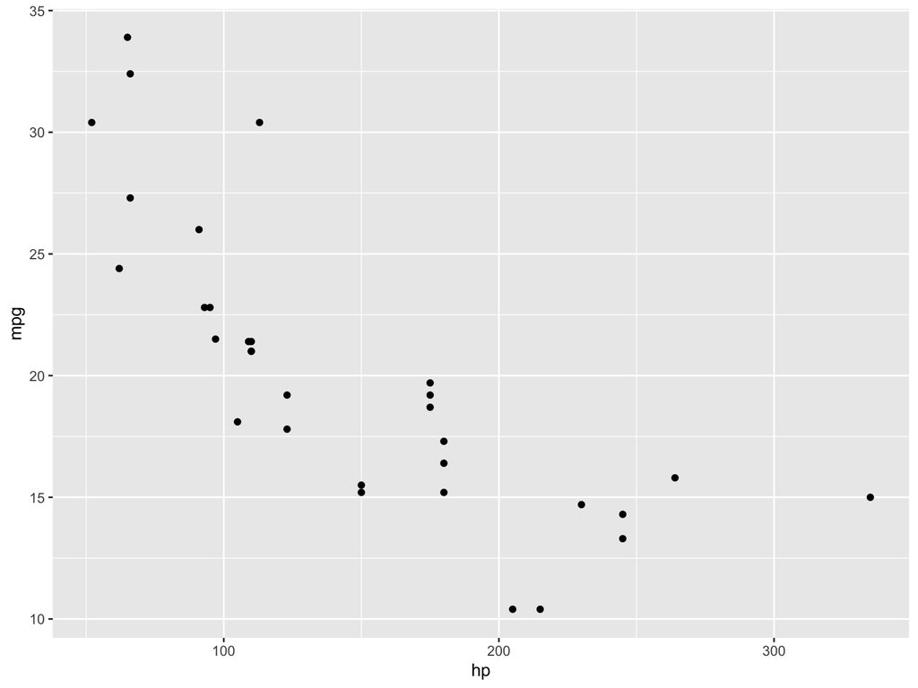

```r
library(ggplot2)

df <- mtcars

# plot mpg against hp
ggplot(df) +
  geom_point(aes(x = hp, y = mpg))
```

```r
# remove hp column
df <- df[,-4]
```

### ‘could not find function’

```r
# trying to create a column called six_cylinder_TF that returns TRUE when the cyl column has a value of 6 and FALSE when it does not
try(
mutate(
  mtcars,
  six_cylinder_TF = cyl==6
  )
)
```

```
## Error in mutate(mtcars, six_cylinder_TF = cyl == 6) :
##   could not find function "mutate"
```

```r
library(dplyr)
try(
  mutate(
  mtcars,
  six_cylinder_TF = cyl==6
  )
)
```

```
##     mpg cyl  disp  hp drat    wt  qsec vs am gear carb six_cylinder_TF
## 1  21.0   6 160.0 110 3.90 2.620 16.46  0  1    4    4            TRUE
## 2  21.0   6 160.0 110 3.90 2.875 17.02  0  1    4    4            TRUE
## 3  22.8   4 108.0  93 3.85 2.320 18.61  1  1    4    1           FALSE
## 4  21.4   6 258.0 110 3.08 3.215 19.44  1  0    3    1            TRUE
## 5  18.7   8 360.0 175 3.15 3.440 17.02  0  0    3    2           FALSE
## 6  18.1   6 225.0 105 2.76 3.460 20.22  1  0    3    1            TRUE
## 7  14.3   8 360.0 245 3.21 3.570 15.84  0  0    3    4           FALSE
## 8  24.4   4 146.7  62 3.69 3.190 20.00  1  0    4    2           FALSE
## 9  22.8   4 140.8  95 3.92 3.150 22.90  1  0    4    2           FALSE
## 10 19.2   6 167.6 123 3.92 3.440 18.30  1  0    4    4            TRUE
## 11 17.8   6 167.6 123 3.92 3.440 18.90  1  0    4    4            TRUE
## 12 16.4   8 275.8 180 3.07 4.070 17.40  0  0    3    3           FALSE
## 13 17.3   8 275.8 180 3.07 3.730 17.60  0  0    3    3           FALSE
## 14 15.2   8 275.8 180 3.07 3.780 18.00  0  0    3    3           FALSE
```

[output cut: 18 more lines]

- You misspelled the function or got the case wrong.

```r
try(
  mtuate(
  mtcars,
  six_cylinder_TF = cyl==6
  )
)
```

```
## Error in mtuate(mtcars, six_cylinder_TF = cyl == 6) :
##   could not find function "mtuate"
```

```r
try(
  Mutate(
  mtcars,
  six_cylinder_TF = cyl==6
  )
)
```

```
## Error in Mutate(mtcars, six_cylinder_TF = cyl == 6) :
##   could not find function "Mutate"
```

### ‘object not found’

This error happens when you call an object in a command, but R doesn't have an object with that name in memory.

```r
# make a copy of the mtcars data set in an object names 'mydata'
mydata <- mtcars

# try to print the first six rows of the object you just created
try(
  head(mydat)
)
```

```
## Error in head(mydat) : object 'mydat' not found
```

```r
# oops.

try(
  head(MyData)
)
```

```
## Error in head(MyData) : object 'MyData' not found
```

```r
# nope

try(
  head(mydata)
)
```

```
##                    mpg cyl disp  hp drat    wt  qsec vs am gear carb
## Mazda RX4         21.0   6  160 110 3.90 2.620 16.46  0  1    4    4
## Mazda RX4 Wag     21.0   6  160 110 3.90 2.875 17.02  0  1    4    4
## Datsun 710        22.8   4  108  93 3.85 2.320 18.61  1  1    4    1
## Hornet 4 Drive    21.4   6  258 110 3.08 3.215 19.44  1  0    3    1
## Hornet Sportabout 18.7   8  360 175 3.15 3.440 17.02  0  0    3    2
## Valiant           18.1   6  225 105 2.76 3.460 20.22  1  0    3    1
```

```r
# nailed it
```

### : there is no package called 'blahblah'

```r
try(
  library(bestPackageEver)
)
```

```
## Error in library(bestPackageEver) :
##   there is no package called 'bestPackageEver'
```

### Indexing Errors

```r
# how many rows does mtcars have?
nrow(mtcars)
```

```
## [1] 32
```

```r
# how many columns?
ncol(mtcars)
```

```
## [1] 11
```

```r
# let's try to get the 29th row and all the columns
df <- data.frame(mtcars)
try(
  df[29,]
)
```

```
##                 mpg cyl disp  hp drat   wt qsec vs am gear carb
## Ford Pantera L 15.8   8  351 264 4.22 3.17 14.5  0  1    5    4
```

```r
#  let's try to get the 15th column and all the rows
try(
  df[,15]
)
```

```
## Error in `[.data.frame`(df, , 15) : undefined columns selected
```

```r
# let's try to get the 25th through the 40th values of the cyl column
try(
  df$cyl[25:40]
)
```

```
##  [1]  8  4  4  4  8  6  8  4 NA NA NA NA NA NA NA NA
```

```r
# let's get the 10th value in the hp column
try(
  df$hp[10,]
)
```

```
## Error in df$hp[10, ] : incorrect number of dimensions
```

```r
try(
  df$hp[10]
)
```

```
## [1] 123
```

### ‘non-numeric argument to a binary operator’

```r
try(
  1 + 1
)
```

```
## [1] 2
```

```r
try(
'one' + 1
)
```

```
## Error in "one" + 1 : non-numeric argument to binary operator
```

```r
class(1)
```

```
## [1] "numeric"
```

```r
class('one')
```

```
## [1] "character"
```

```r
yesterday <- '2020-09-10'
try(
  yesterday + 1
)
```

```
## Error in yesterday + 1 : non-numeric argument to binary operator
```

```r
class(yesterday)
```

```
## [1] "character"
```

```r
yesterday <- as.Date('2020-09-10')
try(
  yesterday + 1
)
```

```
## [1] "2020-09-11"
```

```r
class(yesterday)
```

```
## [1] "Date"
```

### 'replacement has'

```r
# let's make a row number column for our copy of mtcars
df <- mtcars
nrow(df)
```

```
## [1] 32
```

```r
try(
  df$row_number <- 1:30
)
```

```
## Error in `$<-.data.frame`(`*tmp*`, row_number, value = 1:30) :
##   replacement has 30 rows, data has 32
```

```r
try(
  df$row_number <- 1:32
)
# or an even better way to do it
try(
  df$row_number <- 1:nrow(df)
)

# or let's take the iris data set and put one of its columns onto the mtcars data
df1 <- mtcars
df2 <- iris

try(
  df1$sepal_length <- df2$Sepal.Length
)
```

```
## Error in `$<-.data.frame`(`*tmp*`, sepal_length, value = c(5.1, 4.9, 4.7,  :
##   replacement has 150 rows, data has 32
```

```r
try(
  df1$sepal_length <- df2$Sepal.Length[1:nrow(df1)]
)
summary(df1)
```

```
##       mpg             cyl             disp             hp
##  Min.   :10.40   Min.   :4.000   Min.   : 71.1   Min.   : 52.0
##  1st Qu.:15.43   1st Qu.:4.000   1st Qu.:120.8   1st Qu.: 96.5
##  Median :19.20   Median :6.000   Median :196.3   Median :123.0
##  Mean   :20.09   Mean   :6.188   Mean   :230.7   Mean   :146.7
##  3rd Qu.:22.80   3rd Qu.:8.000   3rd Qu.:326.0   3rd Qu.:180.0
##  Max.   :33.90   Max.   :8.000   Max.   :472.0   Max.   :335.0
##       drat             wt             qsec             vs
##  Min.   :2.760   Min.   :1.513   Min.   :14.50   Min.   :0.0000
##  1st Qu.:3.080   1st Qu.:2.581   1st Qu.:16.89   1st Qu.:0.0000
##  Median :3.695   Median :3.325   Median :17.71   Median :0.0000
##  Mean   :3.597   Mean   :3.217   Mean   :17.85   Mean   :0.4375
##  3rd Qu.:3.920   3rd Qu.:3.610   3rd Qu.:18.90   3rd Qu.:1.0000
##  Max.   :4.930   Max.   :5.424   Max.   :22.90   Max.   :1.0000
##        am              gear            carb        sepal_length
##  Min.   :0.0000   Min.   :3.000   Min.   :1.000   Min.   :4.300
##  1st Qu.:0.0000   1st Qu.:3.000   1st Qu.:2.000   1st Qu.:4.800
##  Median :0.0000   Median :4.000   Median :2.000   Median :5.000
##  Mean   :0.4062   Mean   :3.688   Mean   :2.812   Mean   :5.031
##  3rd Qu.:1.0000   3rd Qu.:4.000   3rd Qu.:4.000   3rd Qu.:5.250
##  Max.   :1.0000   Max.   :5.000   Max.   :8.000   Max.   :5.800
```

## Honorable Mentions

- ‘: cannot open the connection’
- ‘Error in if’

## Debugging

- execute one line at a time until you get to the line that causes the error.
- Check the line for syntax mistakes
- talk yourself through what I want the command to do
- google it. :)

> Another effective technique is to explain your code to someone else. This will often cause you to explain the bug to yourself. Sometimes it takes no more than a few sentences, followed by an embarrassed “Never mind, I see what's wrong. Sorry to bother you.” This works remarkably well; you can even use non-programmers as listeners. One university computer center kept a teddy bear near the help desk. Students with mysterious bugs were required to explain them to the bear before they could speak to a human counselor.